# R Notebook

# let us check for data with negative ride length

```r
tripdata <- tripdata[tripdata$ride_length>0,]
```

#let us check if there is ride_length more than 1 day (86400 seconds or 1440 mins).

```r
sum(tripdata$ride_length > 1440, na.rm = TRUE)
```

```
[1] 5452
```

in the above case there is 5452 cases which have more than 1440

#check for extreme outliner

```r
max(tripdata$ride_length, na.rm = TRUE)
```

```
[1] 41387.25
```

```r
min(tripdata$ride_length, na.rm = TRUE)
```

```
[1] 0.01666667
```

```r
#check for mean and median
mean(tripdata$ride_length, na.rm = TRUE)
```

```
[1] 19.12117
```

```r
median(tripdata$ride_length, na.rm = TRUE)
```

```
[1] 10.08333
```

```r
summary(tripdata$ride_length)
```

```
   Min. 1st Qu.  Median    Mean 3rd Qu.    Max.    NA's
    0.0     5.7    10.1    19.1    18.1 41387.2  701339
```

Step 8: Aggregate to analyze the data based on user type: member vs casual

```r
aggregate(tripdata$ride_length ~ tripdata$member_casual, FUN = mean ,na.rm = TRUE)
```

| tripdata$member_casual | tripdata$ride_length |
| --- | --- |
| casual | 28.68051 |
| member | 12.55368 |

```r
aggregate(tripdata$ride_length ~ tripdata$member_casual, FUN = median ,na.rm = TRUE)
```

| tripdata$member_casual | tripdata$ride_length |
| --- | --- |
| casual | 12.650000 |
| member | 8.733333 |

#average ride time by each day for members vs casual

```r
tripdata$day_of_week <- ordered(weekdays(as.Date(tripdata$started_at)), levels = c("Sunday", "Monday", "Tuesday", "Wednesday", "Thursday", "Friday", "Saturday"))
aggregate(tripdata$ride_length ~ tripdata$member_casual + tripdata$day_of_week, FUN = mean, na.rm = TRUE)
```

| tripdata$member_casual | tripdata$day_of_week | tripdata$ride_length |
| --- | --- | --- |
| casual | Sunday | 33.35896 |
| member | Sunday | 13.88904 |
| casual | Monday | 28.16675 |
| member | Monday | 11.97298 |
| casual | Tuesday | 26.68281 |
| member | Tuesday | 12.08378 |
| casual | Wednesday | 24.09085 |
| member | Wednesday | 11.97700 |
| casual | Thursday | 25.68644 |
| member | Thursday | 12.15656 |

[output cut: 4 more lines]

```r
NA
```

```r
head(count(tripdata, start_station_name, member_casual,  rideable_type, sort= TRUE))
```

|  | start_station_name | member_casual | rideable_type | n |
| --- | --- | --- | --- | --- |
| 1 | NA | NA | NA | 701339 |
| 2 |  | member | electric_bike | 486385 |
| 3 |  | casual | electric_bike | 353854 |
| 4 | Streeter Dr & Grand Ave | casual | classic_bike | 29735 |
| 5 | Streeter Dr & Grand Ave | casual | electric_bike | 18427 |
| 6 | DuSable Lake Shore Dr & Monroe St | casual | classic_bike | 15916 |

```r
head(count(tripdata, end_station_name, member_casual,  rideable_type, sort= TRUE))
```

|  | end_station_name | member_casual | rideable_type | n |
| --- | --- | --- | --- | --- |
| 1 | NA | NA | NA | 701339 |
| 2 |  | member | electric_bike | 482237 |
| 3 |  | casual | electric_bike | 410391 |
| 4 | Streeter Dr & Grand Ave | casual | classic_bike | 30581 |
| 5 | Streeter Dr & Grand Ave | casual | electric_bike | 18319 |
| 6 | DuSable Lake Shore Dr & North Blvd | casual | classic_bike | 16890 |

Step 10: Analyze ridership data by type and weekday

```r
tripdata %>%
  mutate(weekday = wday(started_at, label = TRUE)) %>%
  group_by(member_casual, weekday) %>%
  summarise(number_of_rides = n(),
            average_duration = mean(ride_length)) %>%
  arrange(member_casual, weekday)
```

| member_casual | weekday | number_of_rides | average_duration |
| --- | --- | --- | --- |
| casual | Sun | 400677 | 33.36759 |
| casual | Mon | 287037 | 28.41988 |
| casual | Tue | 294543 | 26.25389 |
| casual | Wed | 302540 | 24.57748 |
| casual | Thu | 314952 | 25.27853 |
| casual | Fri | 350532 | 28.02311 |
| casual | Sat | 469989 | 31.77588 |
| member | Sun | 409272 | 13.88209 |
| member | Mon | 499713 | 11.98718 |
| member | Tue | 564033 | 12.07471 |

[output cut: 5 more lines]

```r
NA
```

Step 11: Visualize the number of rides by rider types AND average duration

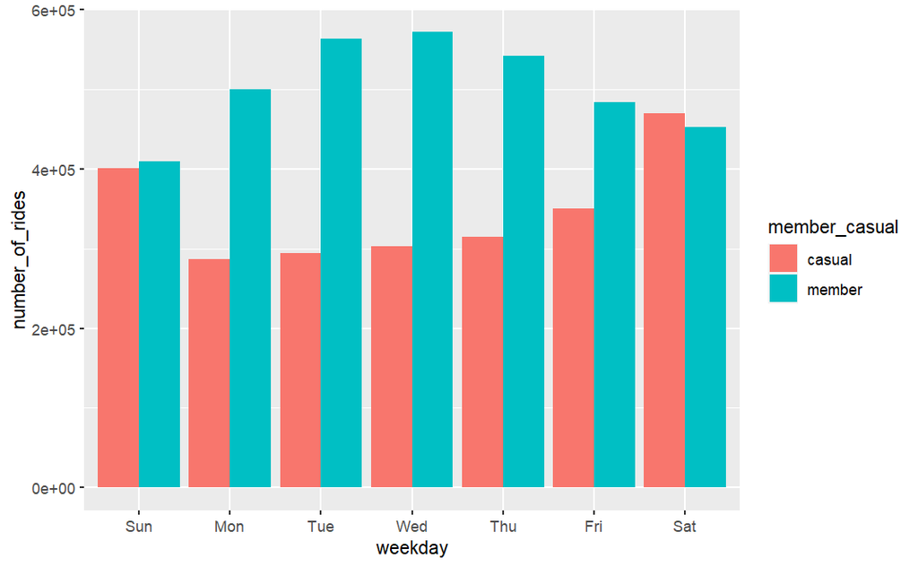

```r
par(mfrow = c(2, 2))

tripdata %>%
  mutate(weekday = wday(started_at, label = TRUE)) %>%
  group_by(member_casual, weekday) %>%
  summarise(number_of_rides = n(), average_duration = mean(ride_length)) %>%
  na.omit() %>%
  arrange(member_casual, weekday) %>%
  ggplot(aes(x = weekday, y = number_of_rides, fill = member_casual)) +
  geom_col(position = "dodge")
```

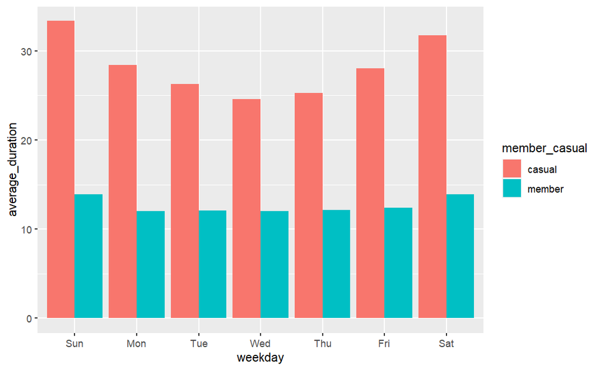

```r
tripdata %>%
  mutate(weekday = wday(started_at, label = TRUE)) %>%
  group_by(member_casual, weekday) %>%
  summarise(number_of_rides = n(), average_duration = mean(ride_length)) %>%
  na.omit() %>%
  arrange(member_casual, weekday) %>%
  ggplot(aes(x = weekday, y = average_duration, fill = member_casual)) +
  geom_col(position = "dodge")
```

Step 12: Visualize Member vs Casual on short ride (less and one hour)

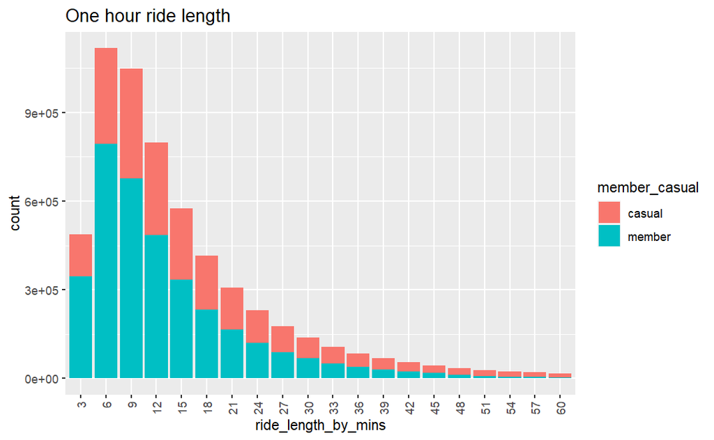

```r
one_hour_data <- tripdata %>% filter(ride_length < 60)
one_hour_data$ride_length_by_mins <- cut(one_hour_data$ride_length,breaks = 20)

ggplot(data = one_hour_data) +
  geom_bar(mapping = aes(x = ride_length_by_mins, fill = member_casual)) +
  labs(title = "One hour ride length") +
  theme(axis.text.x = element_text(angle = 90, vjust = 0.5, hjust=1)) +
  scale_x_discrete(labels=c("3", "6", "9", "12", "15", "18", "21", "24", "27", "30", "33", "36", "39", "42", "45", "48", "51", "54", "57", "60"))
```

Step 13: Visualize day of the week riding choices between member vs causal

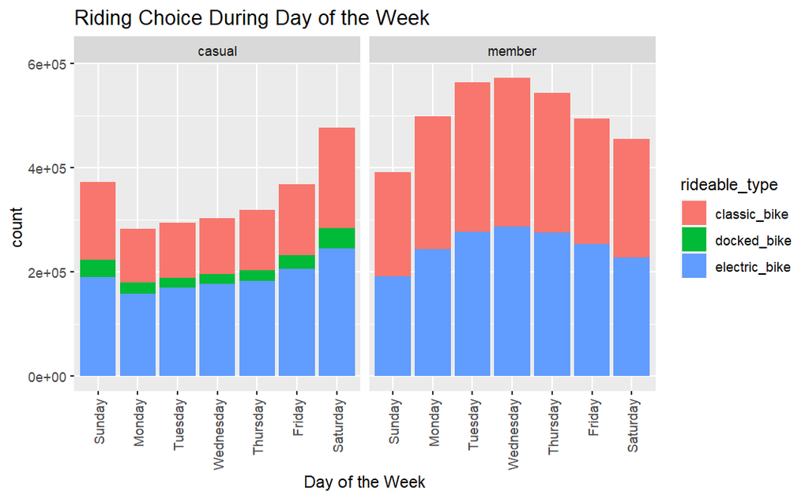

```r
tripdata_clean <- tripdata[!is.na(tripdata$day_of_week), ]  # Filter out NA values in day_of_week

ggplot(data = tripdata_clean) +
  geom_bar(mapping = aes(x = factor(day_of_week), fill = rideable_type)) +
  facet_wrap(~ member_casual) +
  labs(title = 'Riding Choice During Day of the Week', x = 'Day of the Week') +
  theme(axis.text.x = element_text(angle = 90, vjust = 0.5, hjust = 1))
```

```r
NA
NA
```

Step 14: Check for peak time for bike usage between member vs casual

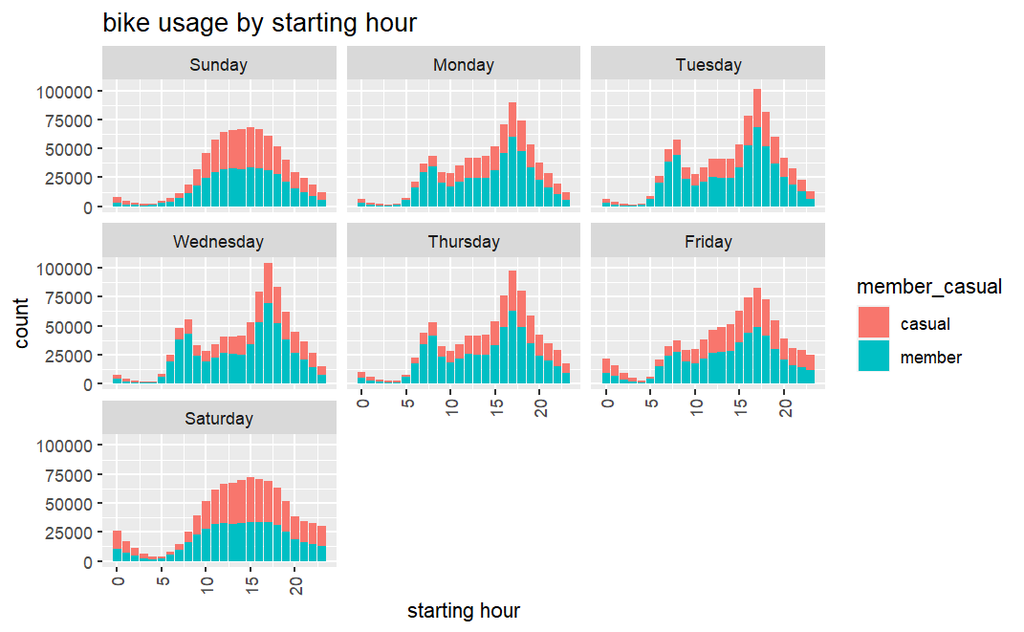

```r
hour_data <- tripdata
hour_data$start_hour <- as.numeric(format(strptime(tripdata$started_at, "%Y-%m-%d %H:%M:%OS"), '%H'))

hour_data <- hour_data[complete.cases(hour_data$start_hour),]  # Remove NA values

ggplot(data = hour_data) +
  geom_bar(mapping = aes(x = start_hour, fill = member_casual), stat = 'count') +
  facet_wrap(~factor(day_of_week)) +
  labs(title = "bike usage by starting hour", x = "starting hour") +
  theme(axis.text.x = element_text(angle = 90, vjust = 0.5, hjust = 1))
```

```r
NA
NA
NA
NA
```

Step 15: Save as csv for further analysis and visualization in Tableau

```r
#the data frame
write_csv(tripdata, "bikedata.csv")
```

```r
#total and average weekly rides by rider type
summary_ride_weekly <- tripdata %>%
  mutate(weekday = wday(started_at, label = TRUE)) %>%
  group_by(member_casual, weekday) %>%
  summarise(number_of_rides = n()
            ,average_duration = mean(ride_length)) %>%
  arrange(member_casual, weekday)

write_csv(summary_ride_weekly, "summary_ride_weekly.csv")

#total and average weekly rides by rider type
summary_ride_weekly_type <- tripdata %>%
  mutate(weekday = wday(started_at, label = TRUE)) %>%
  group_by(member_casual, weekday, rideable_type) %>%
  summarise(number_of_rides = n()
            ,average_duration = mean(ride_length)) %>%
  arrange(member_casual, weekday)

write_csv(summary_ride_weekly_type, "summary_ride_weekly_type.csv")

#total and avg monthly rides by rider type
summary_month <- tripdata %>%
  mutate(month = month(started_at, label = TRUE)) %>%
  group_by(month,member_casual) %>%
  summarise(number_of_rides = n()
            ,average_duration = mean(ride_length)) %>%
  arrange(month, member_casual)
write_csv(summary_month, "summary_ride_monthly.csv")

#most popular stations
popular_stations <- tripdata %>%
  mutate(station = start_station_name) %>%
  drop_na(start_station_name) %>%
  group_by(start_station_name, member_casual) %>%
  summarise(number_of_rides=n())

write_csv(popular_stations, "popular_stations.csv")

#total membership types and rideable types
total_riders <- data.frame(table(tripdata$member_casual))
total_types <- data.frame(table(tripdata$rideable_type))

write_csv(total_riders, "total_riders.csv")
write_csv(total_types, "total_types.csv")
```